# Prediction of how well barbell lifts is performed using data from accelerometers on the belt, forearm, arm, and dumbell

Ghada Abu Sheasha

Sunday, October 25, 2015

# Synopsis

# Loading the data

```r
if (!file.exists("pml-training.csv")) {
  download.file("https://d396qusza40orc.cloudfront.net/predmachlearn/pml-training.csv",method = "auto",destfile = "pml-training.csv")
}
if (!file.exists("pml-testing.csv")) {
  download.file("https://d396qusza40orc.cloudfront.net/predmachlearn/pml-testing.csv",method = "auto",destfile = "pml-testing.csv")
}
training<-read.csv("pml-training.csv",stringsAsFactors=F,na.strings=c("","#DIV/0!","NA"))
testing<-read.csv("pml-testing.csv",stringsAsFactors=F,na.strings=c("","#DIV/0!","NA"))
```

# Preprocessing of the data file

## Cleaning of the data file

I cleaned the data file by removing all irrelevant and useless predictors ### Rememoving irrelevant variables first I removed all the variables that were unrelated to the prediction. i.e., the first seven variables

```r
training<-training[,8:160]
testing<-testing[,8:160]
```

### Removing useless varibles

Then, I removed all variables with zero variance as they will of no value in prediction

```r
nsv<-nearZeroVar(training)
training<-(training[-nsv])
testing<-(testing[-nsv])
```

## Pre-processing of the data file

Before pre-processing of the data, I have to remove the outcome varialbe-after saving it in an object named outcome-and convert the variables into numeric variables

```r
#save the training$class into outcome
outcome<-training$classe
#Remove the outcome variable
training$classe<-NULL
#Convert all variable into numeric
new<-sapply(training,as.numeric)
#convert the dataframe into notcentered
notcentered<-as.data.frame(new)
```

I imputed missing values using knn method

```r
preProc3<-preProcess(notcentered,method="knnImpute")
imputed<-predict(preProc3,notcentered)
```

# Fitting of a randomforest model

Before I applied the model, I splited into training data set into train and test

```r
imputed$classe<-outcome
set.seed(123)
inTrain <- createDataPartition(y=imputed$classe,p=0.75, list=FALSE)
train <- imputed[inTrain,]
test <- imputed[-inTrain,]
rbind("original dataset" = dim(imputed),
      "training set" = dim(train),
      "testing set"=dim(test))
```

```
##                   [,1] [,2]
## original dataset 19622  118
## training set     14718  118
## testing set       4904  118
```

I trained the random forest model.

```r
#Train a randomForest model
y<-train$classe
y<-as.factor(y)
x<-train[,1:117]
# define training control
train_control <- trainControl(method="cv", number=3)
# train the model
model <- train(x,y, trControl=train_control, method="rf")
# make predictions
predictionstraining <- predict(model, x)
# summarize results
confusionMatrix(predictionstraining, y)$overall[1]
```

```
## Accuracy
##        1
```

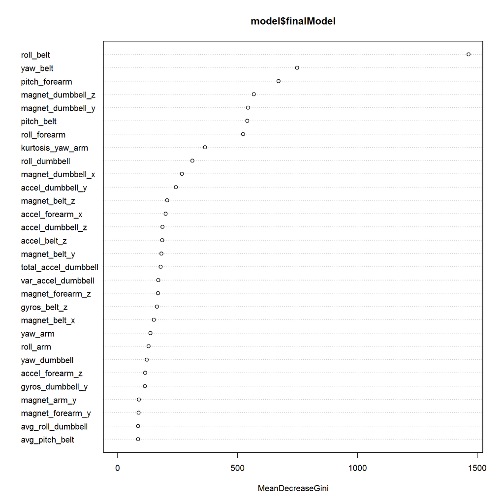

```r
##PLot used variables

varImpPlot(model$finalModel)
```

I save the indices of the important pedictors in a vector named imp. I used to select the important predictors in the new model. Then, I trained the new model on the selected predictors only

```r
imp<-varImp(model)

a<-order(-imp$importance)[1:30]

x2<-train[,a]
modFit2 <- train(x2,y, method="rf",trControl=train_control)
# make predictions
predictionstraining2 <- predict(modFit2, x2)
# summarize results
confusionMatrix(predictionstraining2, y)$overall[1]
```

```
## Accuracy
##        1
```

To evaluate the perfromance of the two models, the redudnant model- the model with all the predictor- and the concise model- the model containing the most important 30 predictors only. The performance of the concise model is a little higher than that of the redundant model althought it uses only 30 predictors.Thus, we will use the concise model

```r
#Predict the performance of the redundant model
predictions=predict(model,test)
#Predict the performance of the consice model
predictions2=predict(modFit2,test)
rbind("Accuracy of the redundant model"=confusionMatrix(test$classe,predictions)$overall[1], "Accuracy of the concise model"=confusionMatrix(test$classe,predictions2)$overall[1])
```

```
##                                  Accuracy
## Accuracy of the redundant model 0.9912316
## Accuracy of the concise model   0.9922512
```

# Predict the test set

First, we have to prepare the testing set to be used for prediction. We have to convert it into numeric variables before imputing the missing values

```r
testing$classe<-NULL
newTest<-sapply(testing,as.numeric)
notcenteredTest<-as.data.frame(newTest)
imputedTest<-predict(preProc3,notcenteredTest[,1:117])
```

I used the concise model to predict the outcome variable in the test set

```r
predictTest2<-predict(modFit2,imputedTest)
```

I used the following function to save the differet predicted values into 20 text file for submission

```r
pml_write_files = function(x){
  n = length(x)
  for(i in 1:n){
    filename = paste0("problem_id_",i,".txt")
    write.table(x[i],file=filename,quote=FALSE,row.names=FALSE,col.names=FALSE)
  }
}
pml_write_files(predictTest2)
```

Upon evaluating the model on the test set (n=20), all the resutls were correct